# Incarceration Trends in the U.S. by Urbanicity

### Variable Comparison Chart

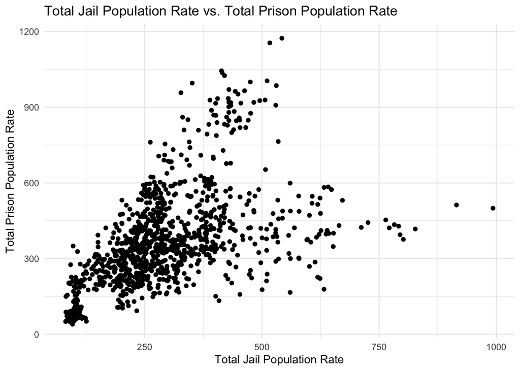

### Map

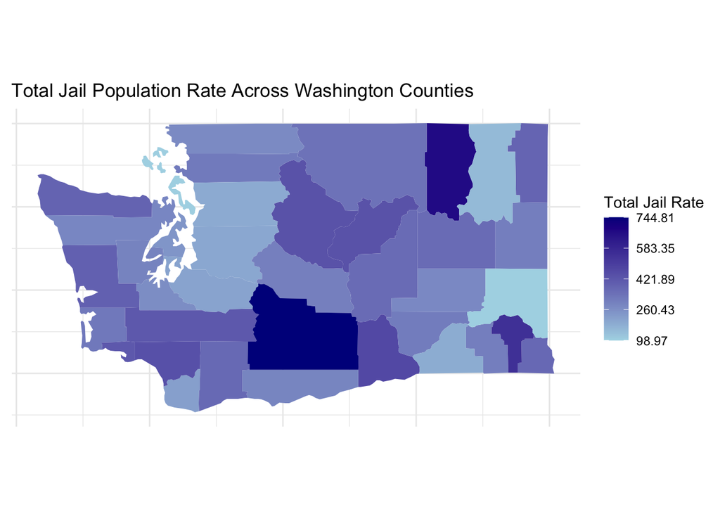

- In the mapping of incarceration rates across various counties in Washington, a notable pattern emerges with the highest concentrations in Yakima and Ferry counties, which are characterized as rural areas. Conversely, more urbanized regions like the Puget Sound display a lighter color, indicating lower incarceration rates. These counties are depicted with contrasting shades on the map, allowing for an immediate identification of areas with differing levels of imprisonment. The stark difference between the rural and urban areas emphasizes a broader trend that seems to link rural counties with higher levels of incarceration while urban areas appear to have relatively lower rates. Whether driven by socio-economic factors, policies, or other variables, this pattern prompts further investigation into the underlying reasons for such disparate distributions between urban and rural regions, raising questions about the justice system and its interactions with different community environments.